# Лекция 14. Отбор по ненаблюдаемым: метод Альтонджи–Элдера–Табера

Блок 3. Естественные эксперименты и отбор по ненаблюдаемым

Карен Аванесян

Каузальный анализ в R на данных RLMS-HSE

# Зачем

## Когда нет ни эксперимента, ни инструмента

- Влияют ли психические расстройства на занятость? Рандомизировать нельзя; хороших инструментов почти нет; люди с расстройствами отличаются и тем, чего мы не видим (здоровье, навыки, среда)
- Модель Хекмана (лекция 13) оценивает корреляцию ненаблюдаемых $\rho$ — но только при правдоподобном исключающем ограничении
- **Altonji, Elder, Taber (2005)**: если $\rho$ оценить нельзя, **задайте его** и посмотрите, при каком $\rho$ эффект исчезает. Ориентир — «отбор по ненаблюдаемым так же силён, как по наблюдаемым»

Это анализ чувствительности, а не оценка эффекта. Результат звучит так: «эффект сохраняется, даже если ненаблюдаемые связаны с отбором так же сильно, как все наши контроли».

## Статья-образец: Chatterji, Alegría, Takeuchi

4 137 взрослых 25–64 лет, NCS-R (США, 2001–2003)

−13.2 п.п. расстройство за 12 мес → занятость, мужчины (пробит)

−4.6 п.п. то же, женщины

−8.9 п.п. мужчины при условии AET (участие в рабочей силе)

что пробовали

### Инструменты не сработали

Расстройства в детстве, депрессия и тревожность у родителей. Авторы сами признают: исключение трудно обосновать, тесты сверхидентификации у женщин его отвергают

что сделали

### Двумерный пробит с заданным $\rho$

$\rho$ от −0.3 до 0.3 и отдельно — $\rho$, при котором отбор по ненаблюдаемым равен отбору по наблюдаемым. Для мужчин эффект устойчив, для женщин — хрупок

## Пример занятия: RLMS 2018

| пол | n | расстройство, % | занятость без расстройства, % | занятость с расстройством, % |
| --- | --- | --- | --- | --- |
| женщины | 5579 | 11.9 | 68.7 | 61.2 |
| мужчины | 4455 | 7.8 | 77.1 | 55.2 |

- Воздействие: «В течение последних 12 месяцев у Вас были серьёзные нервные расстройства?» (`m131`), есть в RLMS 2003–2004 и 2011–2025
- Это самоотчёт, а не клинический диагноз, как в NCS-R. Сравниваем логику, а не цифры

## План занятия

1. Двумерный пробит: два уравнения, одна корреляция
2. Почему $\rho$ не идентифицирован без исключающего ограничения
3. Условие AET: отбор по ненаблюдаемым = отбор по наблюдаемым
4. Своя функция правдоподобия в R и кривая «эффект от $\rho$»
5. Репликация логики Chatterji et al. на RLMS
6. Как читать и писать результат; связь с Остером и `sensemakr`

# Идея

## Двумерный пробит

$$D_i = \mathbb{1}[X_i\gamma + u_i > 0], \qquad Y_i = \mathbb{1}[X_i\beta + \alpha D_i + \varepsilon_i > 0], \qquad \text{corr}(u_i, \varepsilon_i) = \rho$$

- $D$ — расстройство, $Y$ — занятость, $X$ — возраст, образование, семья, город
- $\rho$ — ровно та «скрытая общая причина»: если люди с расстройствами при тех же $X$ и так реже работали бы, то $\rho < 0$
- Обычный пробит $Y$ на $D$ и $X$ = двумерный пробит с **$\rho = 0$**

## Почему $\rho$ не оценить

без исключения

### Идентификация только формой

Если в уравнении $D$ нет переменной, которой нет в уравнении $Y$, $\rho$ держится на нормальности. Правдоподобие почти плоское по $\rho$ — оценка ненадёжна

с исключением

### Это модель Хекмана

Лекция 13: `treatReg` оценивает $\rho$, если есть инструмент. У Chatterji et al. инструменты были, но сомнительные

- Выход AET: перестать притворяться, что $\rho$ известен. Показать, как эффект зависит от $\rho$, и выбрать **содержательный** ориентир для $\rho$

## Условие AET

Отбор по ненаблюдаемым так же силён, как по наблюдаемым:

$$\frac{\text{Cov}(D^*, X\beta)}{\text{Var}(X\beta)} = \frac{\text{Cov}(D^*, \varepsilon)}{\text{Var}(\varepsilon)} \quad\Longrightarrow\quad \rho_{AET} = \frac{\text{Cov}(X\gamma,\, X\beta)}{\text{Var}(X\beta)}$$

**Слева** — насколько индекс наблюдаемых факторов занятости $X\beta$ связан со склонностью к расстройству

**Справа** — то же для ненаблюдаемой части. В пробите $\text{Var}(\varepsilon) = 1$, и правая часть равна $\rho$

**Решаем** уравнение итерациями: оценили модель при $\rho$ → посчитали $\rho_{AET}$ → повторили

## Почему это ориентир, а не истина

- Логика AET: наши $X$ — **случайная выборка** из всех факторов занятости. Тогда невидимые факторы связаны с $D$ так же, как видимые
- На практике исследователь включает **самые важные** контроли первыми — значит, ненаблюдаемые, скорее всего, связаны с $D$ **слабее**. Условие AET — консервативная граница
- Эффект, переживший условие AET, считают устойчивым; эффект, который оно обнуляет, — хрупким

Та же идея, что у δ Остера (лекция 17): там пропорциональность отбора задаётся через $R^2$ линейной модели, здесь — через корреляцию ошибок в пробите.

# Код

## Шаг 1: обычный пробит

```r
probit_ame <- function(d) {
  m <- glm(employed ~ nerv_12m + age + age2 + years_educ + married + n_u18 + urban,
           family = binomial("probit"), data = d)
  xb <- predict(m, newdata = mutate(d, nerv_12m = 0), type = "link")
  mean(pnorm(xb + coef(m)["nerv_12m"]) - pnorm(xb))     # средний предельный эффект, доли
}
mh |> group_by(пол) |> group_modify(\(d, k) tibble(`эффект, п.п.` = 100 * probit_ame(d))) |>
  mutate(across(where(is.double), \(x) round(x, 1)))
```

| пол | эффект, п.п. |
| --- | --- |
| женщины | -4.5 |
| мужчины | -16.8 |

Это двумерный пробит при $\rho = 0$: допущение, что при данных $X$ расстройство «как случайно».

## Шаг 2: своё правдоподобие с заданным $\rho$

- Идея кода
- Код функции

вход

$y$ — занятость, $d$ — расстройство, $X$ — матрица контролей, $\rho$ — **задаём сами**

правдоподобие

Вероятность пары $(y, d)$ = двумерная нормальная функция распределения `pbivnorm()` со знаками $\pm$ для 0/1

выход

Средний предельный эффект $D$ на $P(Y = 1)$, его ошибка (дельта-метод) и $\rho_{AET}$ для итераций

```r
biprob <- function(y, d, X, rho, start = NULL, se = FALSE) {
  k <- ncol(X)
  nll <- function(par) {                                  # минус лог-правдоподобие
    b <- par[1:k]; a <- par[k + 1]; g <- par[(k + 2):(2 * k + 1)]
    xy <- drop(X %*% b) + a * d; xd <- drop(X %*% g)
    qy <- 2 * y - 1; qd <- 2 * d - 1                      # знаки для 0/1
    -sum(log(pmax(pbivnorm(qy * xy, qd * xd, qy * qd * rho), 1e-300)))
  }
  o <- optim(start, nll, method = "BFGS", hessian = se)
  ame_f <- function(par) { xb <- drop(X %*% par[1:k]); mean(pnorm(xb + par[k + 1]) - pnorm(xb)) }
  # ... эффект, ошибка через numDeriv::grad, rho_AET = cov(Xg, Xb) / var(Xb)
}
```

## Шаг 3: кривая «эффект от $\rho$»

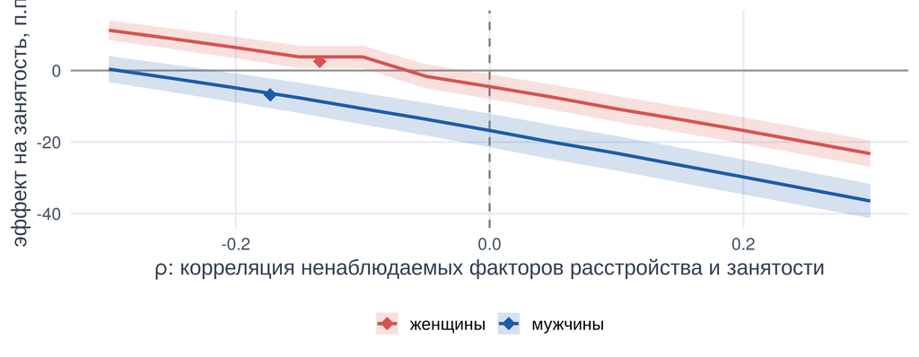

## Как читать кривую

$\rho = 0$

### Обычный пробит

Пунктир. Допущение «нет общих скрытых причин»

$\rho < 0$

### Отрицательный отбор

Люди с расстройствами и так реже работали бы. Часть наблюдаемого разрыва — отбор; эффект **меньше** по модулю

ромб

### Точка AET

$\rho$, при котором отбор по ненаблюдаемым равен отбору по наблюдаемым. Главная строка таблицы

- Вопрос к кривой: **при каком $\rho$ интервал начинает включать ноль?** Если это $\rho$ меньше по модулю, чем $\rho_{AET}$ — результат хрупок

## Шаг 4: итог в таблице

| пол | пробит (ρ = 0), п.п. | s.e. | ρ при условии AET | эффект при AET, п.п. | s.e. |
| --- | --- | --- | --- | --- | --- |
| мужчины | -16.8 | 2.39 | -0.17 | -6.78 | 2.13 |
| женщины | -4.5 | 1.76 | -0.13 | 2.56 | 1.62 |

мужчины

### Эффект переживает условие AET

женщины

### Эффект хрупок

Небольшой отрицательный $\rho$ обнуляет эффект, при условии AET знак меняется. Та же картина, что у Chatterji et al.

## Как писать результат

шаблон

- Обязательно: что задавали ($\rho$), как выбран ориентир (условие AET), какие $X$ определяют «отбор по наблюдаемым»
- Не писать «причинный эффект равен …»: это **граница** при допущении о силе отбора

## Симуляция: истинный $\rho$ известен

- Результат
- Код

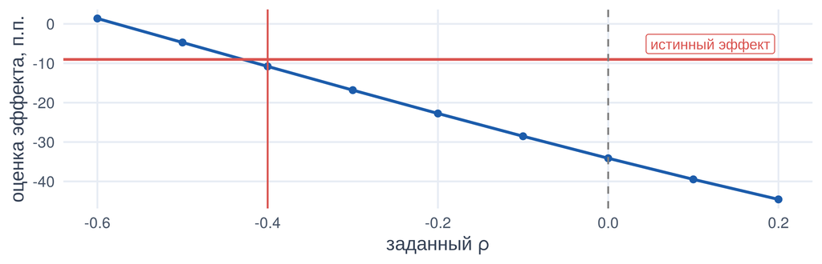

```r
set.seed(7); n <- 6000
x1 <- rnorm(n); x2 <- rnorm(n)
e  <- MASS::mvrnorm(n, c(0, 0), matrix(c(1, -0.4, -0.4, 1), 2))       # истинный ρ = −0.4
d  <- as.integer(-1 + 0.5 * x1 + 0.3 * x2 + e[, 1] > 0)
y  <- as.integer(0.8 + 0.4 * x1 - 0.3 * x2 - 0.3 * d + e[, 2] > 0)
sim_curve <- map_dfr(seq(-0.6, 0.2, 0.1), \(r) tibble(rho = r, ame = biprob(y, d, cbind(1, x1, x2), r)$ame))
```

## AET, Остер и `sensemakr`: одна идея — три формы

AET (2005)

### Бинарные исходы

Двумерный пробит, параметр $\rho$; ориентир — равенство отбора по наблюдаемым и ненаблюдаемым

Остер (2019)

### Линейная модель

Параметр $\delta$ и $R^2_{max}$; движение коэффициента и $R^2$ при добавлении контролей (лекция 17)

Cinelli–Hazlett (2020)

### Любая регрессия

$R^2$ конфаундера с $D$ и $Y$; бенчмарк «в $k$ раз сильнее пола» (лекция 17)

- Все три превращают непроверяемое допущение в **параметр** и спрашивают, насколько сильным должно быть нарушение. Различаются моделью и единицами
- В отчёте полезно показать два: например, AET для пробита и `sensemakr` для линейной вероятностной модели

# Как ошибаются

## Шесть ошибок с методом AET

ошибка 1

### Выдавать оценку при $\rho_{AET}$ за эффект

**Как правильно:** это граница при допущении о силе отбора; формулировать как анализ чувствительности

ошибка 2

### Подбирать $X$ под нужный $\rho_{AET}$

**Как правильно:** зафиксировать набор контролей до анализа; $\rho_{AET}$ зависит от того, что считается «наблюдаемым»

ошибка 3

### Плохие контроли в $X$

**Как правильно:** не включать следствия $D$ (доход, здоровье после расстройства): они искажают и эффект, и ориентир (лекция 3)

## Шесть ошибок с методом AET (2)

ошибка 4

### Одна точка вместо кривой

**Как правильно:** показывать весь диапазон $\rho$ с интервалами и точку, где эффект теряет значимость

ошибка 5

### Обычные ошибки в панели

**Как правильно:** одна волна или бутстрап по `idind`; повторяющиеся люди занижают s.e.

ошибка 6

### Самоотчёт = диагноз

**Как правильно:** помнить об ошибке измерения $D$: она тоже смещает эффект, и AET её не исправляет

## Чек-лист

- Объяснено, почему нет эксперимента и правдоподобного инструмента
- Набор контролей зафиксирован до анализа, плохих контролей нет
- Показана кривая «эффект от $\rho$» с интервалами
- Названа точка, где эффект теряет значимость, и $\rho_{AET}$
- Вывод сформулирован как граница при допущении о силе отбора
- Для сравнения — `sensemakr` или δ Остера для линейной модели

# Мини-задача

## Задание к следующему занятию

задача 1

### Другое воздействие

Замените `nerv_12m` на «периодическую депрессию» (`depression`, волны 2012, 2019, 2021–2025). Устойчив ли эффект?

**Подсказка:** формулировка `l131_6` — о «характерности», а не о последних 12 месяцах; это ближе к хроническому состоянию

задача 2

### Другой исход

Повторите анализ для зарплаты среди работающих (линейная модель) и сравните с δ Остера и `sensemakr`

**Подсказка:** для непрерывного $Y$ аналог AET — регрессия с эндогенной дамми (`treatReg`) с заданным $\rho$

задача 3

### Бутстрап

Посчитайте 95% интервал для эффекта при $\rho_{AET}$ бутстрапом по людям (200 повторов). Совпадает ли он с дельта-методом?

**Подсказка:** $\rho_{AET}$ пересчитывается в каждом повторе — это часть неопределённости

# Литература

## Что прочитать

- Altonji J., Elder T., Taber C. (2005). Selection on Observed and Unobserved Variables: Assessing the Effectiveness of Catholic Schools. *Journal of Political Economy*
- Chatterji P., Alegría M., Takeuchi D. (2011). Psychiatric Disorders and Labor Market Outcomes: Evidence from the National Comorbidity Survey-Replication. *Journal of Health Economics*; препринт [NBER WP 14404](https://www.nber.org/papers/w14404)
- Chatterji P. et al. (2007). Psychiatric Disorders and Labor Market Outcomes: Evidence from the National Latino and Asian American Study. *Health Economics*; [NBER WP 11893](https://www.nber.org/papers/w11893)
- Oster E. (2019). Unobservable Selection and Coefficient Stability. *JBES* — линейный аналог (лекция 17)
- Krauth B. (2016). Bounding a Linear Causal Effect Using Relative Correlation Restrictions. *Journal of Econometric Methods*

Каузальный анализ в R · RLMS-HSE · К. Аванесян

← К программе курса